# Compare p(X>=2) and p(X>=50%)

November, 2024

Metrics compared for shocks:

1. number of resources per country
2. probability of at least two shocks p(X>=2)
3. probability of at least 50% of shocks p(X>=50%). When there are 2 resources, p(X>=1) is applied, when there are 3-4 resources, p(X>=2) is applied and when there are 5-6 resources p(X>=3) is applied.
4. probability of at least 50% of shocks p(X>=50%)bis. When there are 2 resources, p(X>=1) is applied, when there are 3 resources mean(p(X>=1),p(X>=2) is applied, when there are 4 resources p(X>=2) is applied, when there are 5 resources mean(p(X>=2),p(X>=3)) is applied, and when there are 6 resources p(X>=3) is applied.

Mapping out the p(X>=2), p(X>=50%), and p(X>=50%)bis for the SSP 5.85 climate scenario for shocks:

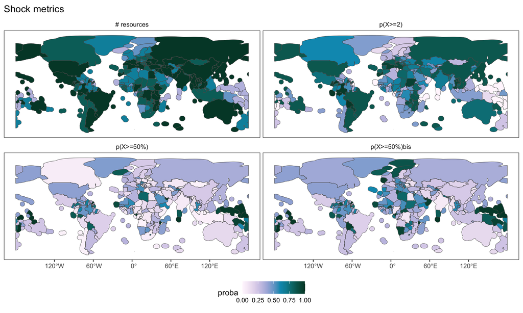

Correlation table of shock metrics:

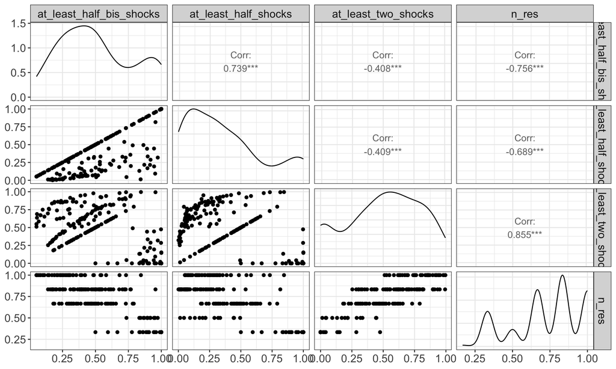

Metrics compared for gradual changes:

1. number of resources per country
2. probability of at least two resources changing beyond 25% p(X>=2)
3. probability of at least 50% of resources changing beyond 25% p(X>=50%). When there are 2 resources, p(X>=1) is applied, when there are 3-4 resources, p(X>=2) is applied and when there are 5-6 resources p(X>=3) is applied.
4. probability of at least 50% of resources changing beyond 25% p(X>=50%)bis. When there are 2 resources, p(X>=1) is applied, when there are 3 resources mean(p(X>=1),p(X>=2) is applied, when there are 4 resources p(X>=2) is applied, when there are 5 resources mean(p(X>=2),p(X>=3)) is applied, and when there are 6 resources p(X>=3) is applied.

Mapping out the p(X>=2), p(X>=50%), and p(X>=50%)bis for the SSP 5.85 climate scenario for gradual changes:

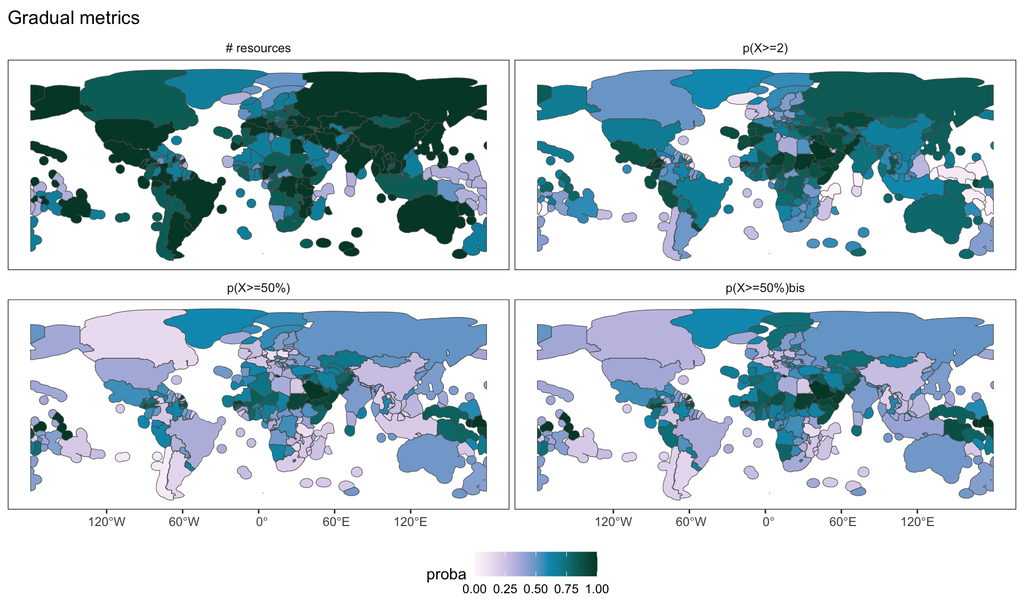

Correlation table of gradual metrics:

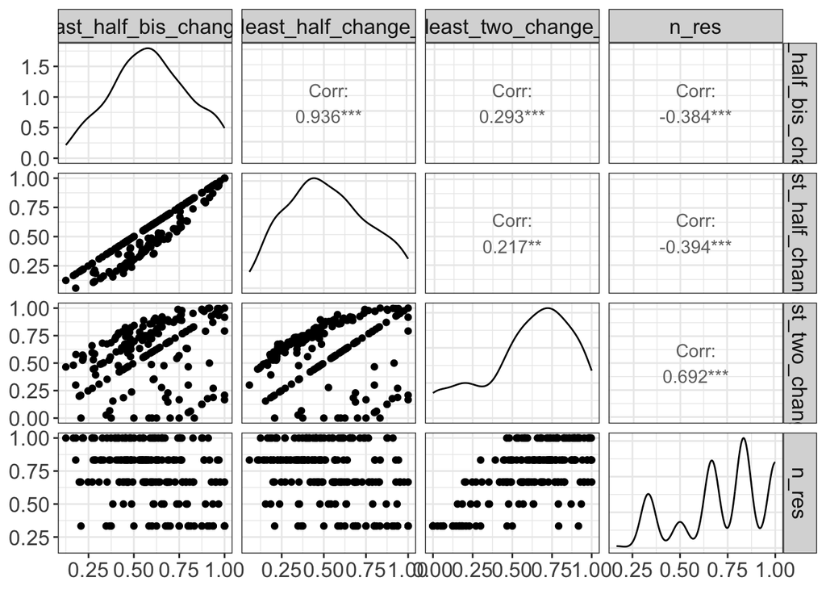